# Global COVID-19 Case and Mortality Patterns Across Development Levels and Regions: An Exploratory Data Analysis

[figure not shown]

> [!NOTE]  
> The **final submission for this assignment is contained in the `main` branch**.

> The branch `20260305-cds-group-2-final-assignment-same-as-main` was used **only during the preparation of the final version** and is retained for reference. It is **not intended for evaluation**.

> **Thank you for taking the time to review our work.**

> [!IMPORTANT] **Regarding Reproducibility — Please Read Before Running the Analysis**

> To ensure that this project can be reproduced exactly, the analysis depends on the **specific R package environment recorded in `renv.lock`.**

> Before running the analysis or rendering the report, please restore the project environment:

> ```r
> renv::restore()
> ```

> This installs the **exact package versions used during development**.

> If the environment is not restored first, the project may:

> • fail to run  
> • encounter missing package errors  
> • produce results or figures that differ from the original analysis

> Thank you for restoring the environment before running the report.

### EPI4934B – Clinical Data Science

**2026 Group Assignment (Group 2)**

This repository contains a **reproducible analysis of global COVID-19 trends**, including:

- Time-series analyses by **continent**
- Time-series analyses by **Human Development Index (HDI)**
- Global **choropleth maps**

All results are generated **directly from code using R and RMarkdown**, ensuring transparency and reproducibility.

# Key Visualisations

### COVID-19 Time-Series by Continent

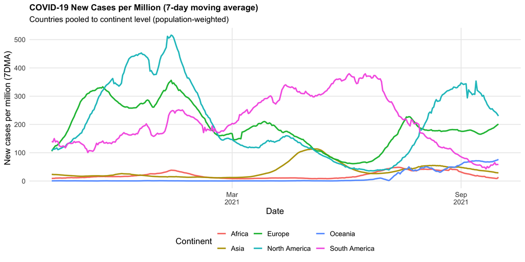

### COVID-19 Time-Series by Human Development Index

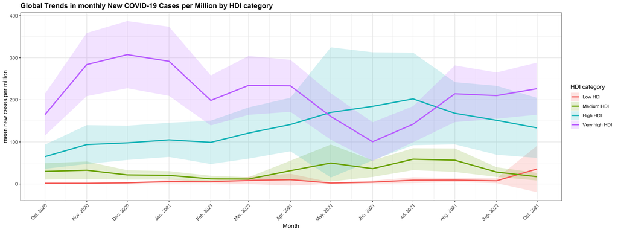

### Global COVID-19 Choropleth Map

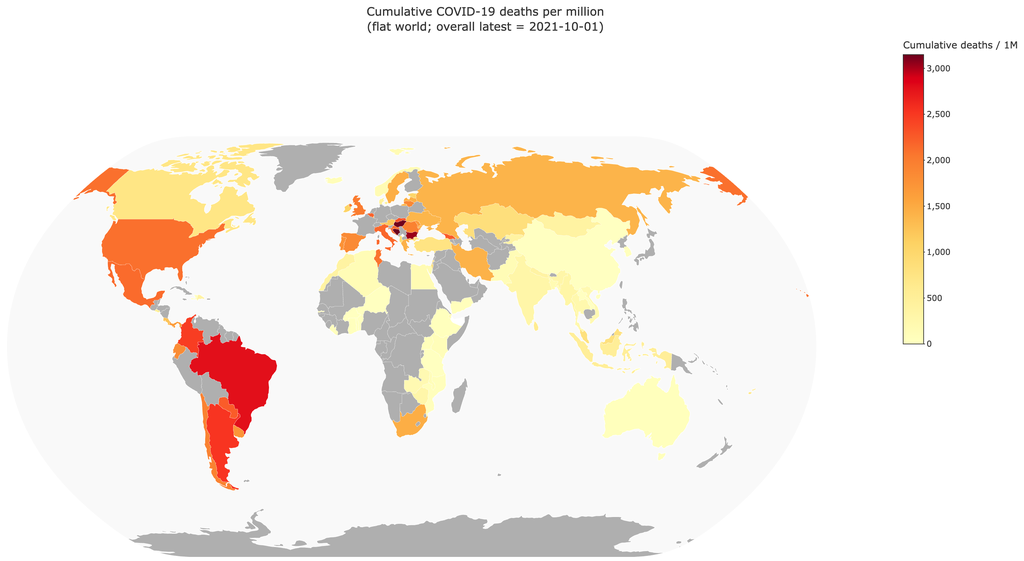

# Running the Analysis

### 1. Restore the environment

```r
renv::restore()
```

### 2. Render the report

```r
rmarkdown::render("EPI4934B_Group_2_Final_Assignment.Rmd")
```

This command will:

- restore the package environment
- load the dataset
- execute the analysis pipeline
- regenerate all figures
- rebuild the final HTML report (`EPI4934B_Group_2_Final_Assignment.html`)

# Repository Structure

```
.
├── EPI4934B_Group_2_Final_Assignment.Rmd
├── EPI4934B_Group_2_Final_Assignment.html
├── EPI4934B_Group_2_Abstract_Figures.pdf
│
├── Reproducible_Environment_Management.Rmd
├── Reproducible_Environment_Management.html
│
├── Figures/
│
├── open_covid_data/
│
├── Outputs_Choropleth_Map_by_Shiqiu/
├── Outputs_Time_Series_Continent_by_Paulina/
├── Outputs_Time_Series_HDI_by_Lin/
│
├── renv/
├── renv.lock
│
├── .gitignore
├── .Rprofile
├── .RData
├── .Rhistory
│
├── README.md
├── README.html
│
└── 2026-Group2.Rproj
```

# Software

- **R**
- **RMarkdown**
- **renv**
- **dplyr**
- **ggplot2**
- **plotly**
- **sf**
- **rnaturalearth**

# Authors

**Group 2 – EPI4934B Clinical Data Science**

- Lin
- Paulina
- Shiqiu (Q)

# Reproducible Research Statement

All figures, tables, and results presented in this repository are generated directly from the analysis code contained in the RMarkdown documents.

The use of **`renv` environment management** ensures that the analysis can be reproduced with identical package versions, supporting transparency, reproducibility, and scientific reliability.